# SumStat

## 4 Simulating a pair of cohorts

In general, the procedure is the same as for simulating a single cohort.

However, for cohort 2 that is derived from the same ancestry as cohort 1, the expected allele frequency $p_{j,2}=p_{j,1}$.

Given the genetic correlation between cohort 1 and 2 is $cor(\mathbf{\beta}_{1}, \mathbf{\beta}_{2})=\gamma_G$, the genetic effect for cohort 2 can be simulated as $\beta_2=\gamma_G\beta_1+\sqrt{1-r^2}\tilde{e}$, in which $\tilde{e} \sim (0, h^2_2)$.

**Directly simulating summary statistics for GWAS**

Assuming the genetic effect is estimated via LSE for the model below

$\mathbf{y}=a+\beta_i \mathbf{g}_i+e$

For locus $j$, its estimated effect is distributed $\hat\beta_i \sim N(\beta_i, \sqrt{\frac{\sigma_y^2-\sigma_{g_i}^2 \beta^2_i}{(n_1-n_u)\sigma_{g_i}^2}})$, in which $E(\sigma_{g_i}^2)=2p_i \bar p_i$, and $\hat{\sigma}_{\beta}^2=\frac{\sigma_y^2-\sigma_{g_i}^2 \beta^2_i}{(n_1-n_u)\sigma_{g_i}^2}$, $n_u$ ($n_c=2$ here for the model above) is the number of parameters in the LSE.

For a pair of cohorts we have summary statistics below

| SNP | Ref Allele$_1$ | Alt Allele$_1$ | Freq$_1$ | Effect$_1$ | SE$_1$ | Ref Allele$_2$ | Alt Allele$_2$ | Effect$_2$ | Freq$_2$ | SE$_2$ |
| --- | --- | --- | --- | --- | --- | --- | --- | --- | --- | --- |
| $SNP_{1}$ | A | C | $\hat{p}_{1.1}$ | $\hat\beta_{1.1}$ | $\hat{\sigma}_{\beta_{1.1}}$ | A | C | $\hat{p}_{1.1}$ | $\hat\beta_{1.2}$ | $\hat{\sigma}_{\beta_{1.2}}$ |
| $\mathbf{SNP}_{2}$ | G | C | $\hat{p}_{2.1}$ | $\hat\beta_{2.1}$ | $\hat{\sigma}_{\beta_{2.1}}$ | G | C | $\hat{p}_{2.1}$ | $\hat\beta_{2.2}$ | $\hat{\sigma}_{\beta_{2.2}}$ |
| $\vdots$ | $\vdots$ | $\vdots$ | $\vdots$ | $\vdots$ | $\vdots$ | $\vdots$ | $\vdots$ | $\vdots$ | $\vdots$ | $\vdots$ |
| $SNP_{m}$ | A | C | $\hat{p}_{m.1}$ | $\hat\beta_{m.1}$ | $\hat{\sigma}_{\beta_{m.1}}$ | A | C | $\hat{p}_{m.1}$ | $\hat\beta_{m.2}$ | $\hat{\sigma}_{\beta_{m.2}}$ |

## 5 Simulating nuclear families

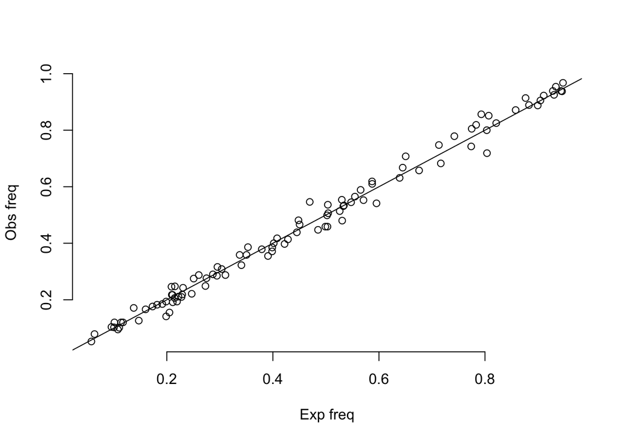

```r
M=100
Kid=2
freq=runif(M, 0.05, 0.95)
hsq=0.5
b=rnorm(M, 0, sqrt(3*hsq/M))
famSize=100
FamG=array(0, dim=c(famSize, (2+Kid)*2, M))
Phe=array(0, (2+Kid)*famSize)
for(f in 1:famSize) {
  for(i in 1:famSize) {
    fg=matrix(c(rbinom(M, 1, freq), rbinom(M, 1, freq)), 2, M, byrow = T)
    mg=matrix(c(rbinom(M, 1, freq), rbinom(M, 1, freq)), 2, M, byrow = T)
    Phe[(f-1)*(2+Kid)+1]= sum(fg[1,]*b+fg[2,]*b)
    Phe[(f-1)*(2+Kid)+2]= sum(mg[1,]*b+mg[2,]*b)

    kg=matrix(0, Kid*2, M)
    for(k in 1:Kid) {
      kg[(k-1)*2+1,] = fg[rbinom(1, 1, 0.5)+1,]
      kg[(k-1)*2+2,] = fg[rbinom(1, 1, 0.5)+1,]
      Phe[(f-1)*(2+Kid)+2+k] = sum(kg[(k-1)*2+1,]*b+kg[(k-1)*2+2,]*b)
    }
    FG=rbind(fg, mg, kg)
    FamG[f,,]=FG
  }
}
plot(freq, colMeans(colMeans(FamG[,,])), xlab="Exp freq", ylab="Obs freq", bty='n')
abline(a=0, b=1)
```

```r
print(var(Phe))
```

```
## [1] 0.441234
```

```r
Phe=Phe+rnorm(length(Phe), 0, sqrt(0.5))
print(var(Phe))
```

```
## [1] 0.939765
```

## 6 Effective overlapping samples$n_e$

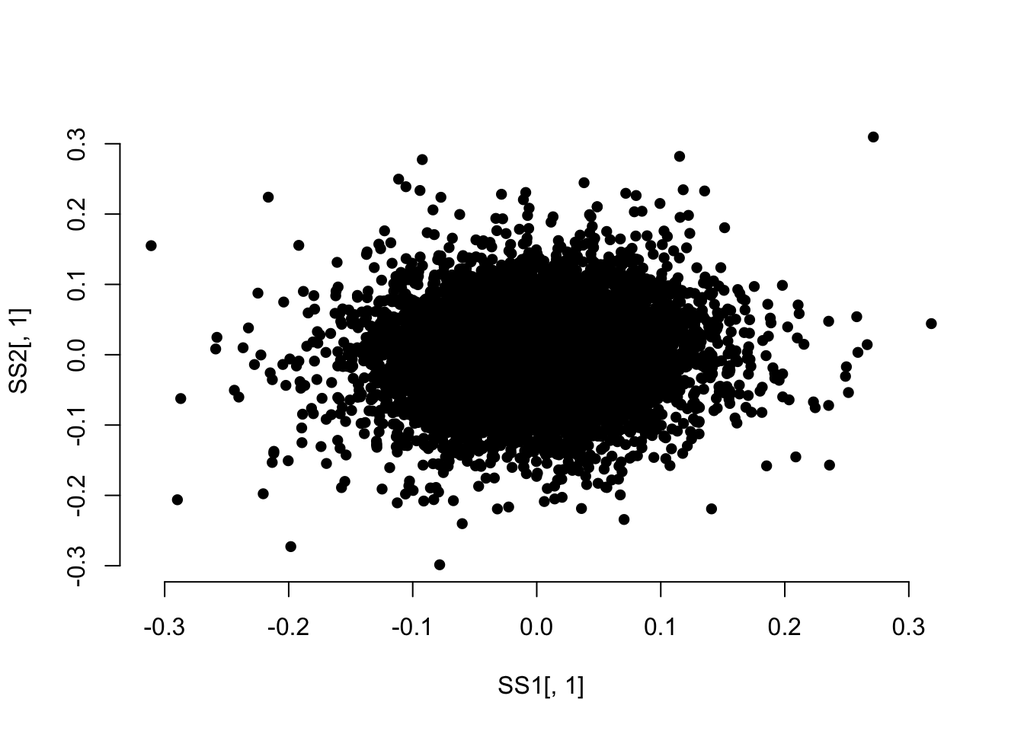

```r
SimuInd <- function(s, m, h2, fq, B) {
  hsq=h2

  Gn=matrix(0, s, m+1)
  for(i in 1:s) {
    Gn[i, 1:m] = rbinom(m, 2, fq)
    Gn[i, m+1] = sum(Gn[i,1:m]*B) + rnorm(1, 0, sqrt(1-h2))
  }
  return(Gn)
}

SimuNuFam <- function (n1, m, k, h2, fq, B) {

  famSize=n1
  M=m
  Kid=k
  hsq=h2

  freq=fq
  b=B
  #  FamG=array(0, dim=c(famSize, (2+Kid)*2, M))
  FamG=array(0, dim=c(famSize, 2+Kid, M+1))

  Phe=array(0, (2+Kid)*famSize)
  for(f in 1:famSize) {
    fg=matrix(c(rbinom(M, 1, freq), rbinom(M, 1, freq)), 2, M, byrow = T)
    mg=matrix(c(rbinom(M, 1, freq), rbinom(M, 1, freq)), 2, M, byrow = T)
    Phe[(f-1)*(2+Kid)+1]= sum(fg[1,1:M]*b+fg[2,1:M]*b) + rnorm(1, 0, sqrt(1-h2))
    Phe[(f-1)*(2+Kid)+2]= sum(mg[1,1:M]*b+mg[2,1:M]*b) + rnorm(1, 0, sqrt(1-h2))
    FamG[f,1,1:M]=apply(fg, 2, sum)
    FamG[f,2,1:M]=apply(mg, 2, sum)

    kg=matrix(0, Kid*2, M)
    for(k in 1:Kid) {
      kg[(k-1)*2+1,] = fg[rbinom(1, 1, 0.5)+1,]
      kg[(k-1)*2+2,] = fg[rbinom(1, 1, 0.5)+1,]
      Phe[(f-1)*(2+Kid)+2+k] = sum(kg[(k-1)*2+1,1:M]*b+kg[(k-1)*2+2,1:M]*b) + rnorm(1, 0, sqrt(1-h2))
      FamG[f,2+k,1:M]=apply(kg[c((k-1)*2+1,(k-1)*2+2),], 2, sum)
    }
  }
  FamG[,,M+1] = Phe
  return(FamG)
}


h2=0.5
M=10000
freq=runif(M, 0.05, 0.95)
b=rnorm(M, 0, sqrt(3*h2/M))

S1=1000 #sample size 1
S2=1000 #sample size 2

n0=100 #overlapping samples
n1=100 #overlapping first-degree relatives

pop1=SimuInd(S1-n0-n1, M, h2, freq, b) #independent sample
pop2=SimuInd(S2-n0-n1, M, h2, freq, b) #independent sample
Gn0=SimuInd(n0, M, h2, freq, b) #overlapping samples
Gn1=SimuNuFam(n1, 10000, 2, h2, freq, b) #nuclear family

sample1=rbind(pop1, Gn0, Gn1[,3,])
sample2=rbind(pop2, Gn0, Gn1[,4,])

SS1=matrix(0, nrow = M, 4)
for(i in 1:M) {
  mod=lm(sample1[,M+1]~sample1[,i])
  SS1[i,]=summary(mod)$coefficient[2,]
}

SS2=matrix(0, nrow = M, 4)
for(i in 1:M) {
  mod=lm(sample2[,M+1]~sample2[,i])
  SS2[i,]=summary(mod)$coefficient[2,]
}
plot(SS1[,1], SS2[,1], bty="n", pch=16)
```

## 7 $\lambda_{meta}$

Given the summary statistics below, we have

| SNP | Ref Allele$_1$ | Alt Allele$_1$ | Freq$_1$ | Effect$_1$ | SE$_1$ | Ref Allele$_2$ | Alt Allele$_2$ | Effect$_2$ | Freq$_2$ | SE$_2$ |
| --- | --- | --- | --- | --- | --- | --- | --- | --- | --- | --- |
| $SNP_{1}$ | A | C | $\hat{p}_{1.1}$ | $\hat\beta_{1.1}$ | $\hat{\sigma}_{\beta_{1.1}}$ | A | C | $\hat{p}_{1.1}$ | $\hat\beta_{1.2}$ | $\hat{\sigma}_{\beta_{1.2}}$ |
| $\mathbf{SNP}_{2}$ | G | C | $\hat{p}_{2.1}$ | $\hat\beta_{2.1}$ | $\hat{\sigma}_{\beta_{2.1}}$ | G | C | $\hat{p}_{2.1}$ | $\hat\beta_{2.2}$ | $\hat{\sigma}_{\beta_{2.2}}$ |
| $\vdots$ | $\vdots$ | $\vdots$ | $\vdots$ | $\vdots$ | $\vdots$ | $\vdots$ | $\vdots$ | $\vdots$ | $\vdots$ | $\vdots$ |
| $SNP_{m}$ | A | C | $\hat{p}_{m.1}$ | $\hat\beta_{m.1}$ | $\hat{\sigma}_{\beta_{m.1}}$ | A | C | $\hat{p}_{m.1}$ | $\hat\beta_{m.2}$ | $\hat{\sigma}_{\beta_{m.2}}$ |

We can estimate $\lambda_{meta}$ statistic as below

$h_i= \frac{(\beta_{j,1}-\beta_{j,2})^2} {\sigma_{j,1}^2+\sigma_{j,2}^2} \sim \chi^2_1$

For $m$ loci, we have $\mathbf{h}$, a $m\times 1$ vector. As the vector $\mathbf{h} \sim \chi^2_1$, we can define $\lambda_{meta}=\frac{median(\mathbf{h})}{0.455}$, in which 0.455 is the quantity for $\chi^2_{1,p=0.5}=0.455$. Under the null hypothesis of no overlapping samples, $E(\lambda_{meta})=1$.

$\hat{\rho}_{\lambda_{meta}}=1-\lambda_{meta}$, and $E(\rho_{\lambda_{meta}})=\frac{n_o}{\sqrt{n_1n_2}}$.

## 8 Various overlapping relatives

1. Overlapping individuals
2. Overlapping relatives

## 9 Meta-analysis

For a pair of cohorts, for the$j^{th}$ locus, we have $\hat\beta_{j,1}$, $\hat{\sigma}^2_{\beta_{j,1}}$, and $\hat\beta_{j,1}$, $\hat{\sigma}^2_{\beta_{j,1}}$.

Using generalized (or weighted) least squares (GLS) estimates the genetic effect

$\mathbf{y}=\mu+e$

in which $\mathbf{y}^T=[\hat{\beta}_{j,1}, \hat{\beta}_{j,2}]$, and
$$e=
\left[
\begin{matrix}
1&\rho_{1,2} \\
\rho_{1,2}&1
\end{matrix}
\right]$$

Correct and incorrect ways in estimating

Correct but subject to heterogeneity: $\hat\rho=1-\lambda_{meta}$

Incorrect and subject to genetic architecture: $\hat\rho=cov(\mathbf{Z}_1, \mathbf{Z}_2)$ or $\hat\rho=cov(\mathbf{\beta}_1, \mathbf{\beta}_2)$

More details for the estimation method can be [1 & 2 are generalized lse, 3 & 4 are chisq test]

1. Am J Hum Genet, “Meta-analysis of genome-wide association studies with overlapping subjects.”, 2009:85, 862-72, **Eq 3-5**
2. Bioinformatics, “METAL: fast and efficient meta-analysis of genomewide association scans”, 2010:26, 2190-1, See their **Table**
3. Zhu Xiaofeng, Am J Hum Genet, 2014, 96:21-36
4. [Mike Goddard, PLoS Genet, 2015,10:e1004198](http://www.pubmedcentral.nih.gov/articlerender.fcgi?artid=3967938&tool=pmcentrez&rendertype=abstract)
5. [Wang et al, Hum Mol Genet, 2013, 22:2303-2311](https://academic.oup.com/hmg/article/22/11/2303/634133)

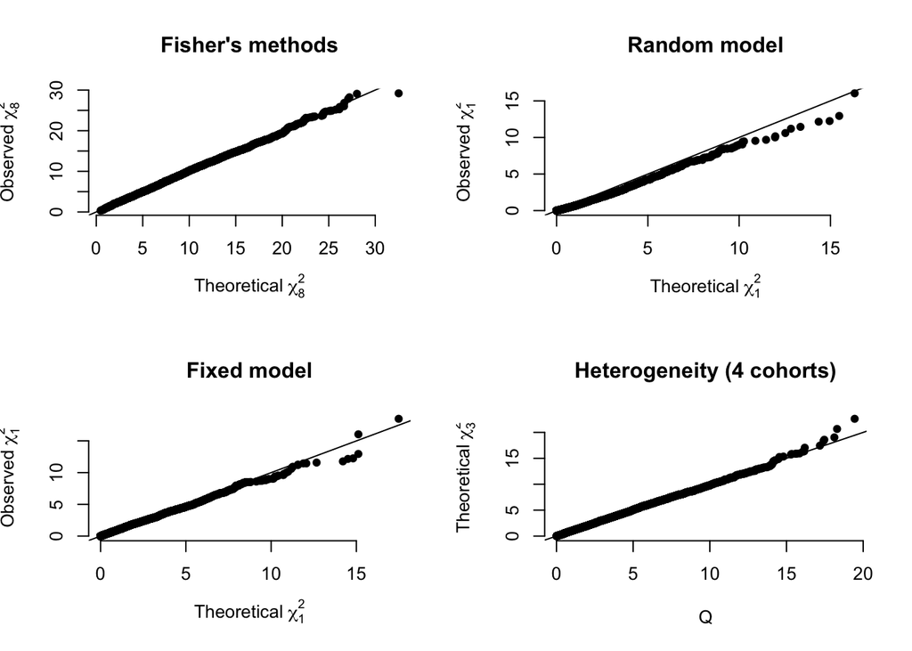

```r
set.seed(1000)
CT=4
N=ceiling(rnorm(CT, 3000, 1000))
M=10000

#freq
P=runif(M, 0.05, 0.95)
Freq=matrix(0, M, CT)
for(i in 1:CT) {
  Freq[,i] = rnorm(M, P, sd=sqrt((P*(1-P))/(2*N[i])))
}

#mat
h2=0.5
Beta=rnorm(M, 0, sd=0)#=sqrt(h2/sum(2*P*(1-P))))
Bmat=matrix(0, M, CT)
Smat=matrix(0, M, CT)
Pmat=matrix(0, M, CT)
for(i in 1:CT) {
  Smat[,i]=1/(N[i]*2*Freq[,i]*(1-Freq[,i]))
  Bmat[,i] = rnorm(M, Beta, sd=sqrt(Smat[,i]))
  Pmat[,i] = (1-pnorm(abs(Bmat[,i]/sqrt(Smat[,i]))))*2
}

#fixed model
FisherP=matrix(0, M, 1)
Fmeta=matrix(0, M, 3)
Qmeta=matrix(0, M, 6)
for(i in 1:M) {
  FisherP[i,1]=-2*sum(log(Pmat[i,]))

  v=1/Smat[i,]
  Fmeta[i,2]=1/sum(v)
  Fmeta[i,1]=sum(Bmat[i,]*v)/sum(v)
  Fmeta[i,3]=Fmeta[i,1]/sqrt(Fmeta[i,2])

  Qmeta[i,4]=sum(v*(Bmat[i,]-Fmeta[i,1])^2)
  Qmeta[i,5]=sum(v)-sum(v^2)/sum(v)
  Qmeta[i,6]=(Qmeta[i,4]-(CT-1))/Qmeta[i,5]
  if(Qmeta[i,6]<0) {
    Qmeta[i,6]=0
  }
  vr=1/(Smat[i,]+Qmeta[i,6])
  Qmeta[i,2]=1/sum(v)+Qmeta[i,6]
  Qmeta[i,1]=sum(vr*Bmat[i,])/sum(vr)
  Qmeta[i,3]=Qmeta[i,1]^2/Qmeta[i,2]
}
layout(matrix(1:4, 2, 2))
qqplot(main="Fisher's methods", xlab=expression(paste("Theoretical ", chi[8]^2)),
       ylab=expression(paste("Observed ", chi[8]^2)),
       FisherP, rchisq(M, 8), bty="n", pch=16)
abline(a=0, b=1)

qqplot(main="Fixed model", xlab=expression(paste("Theoretical ", chi[1]^2)),
       ylab=expression(paste("Observed ", chi[1]^2)),
       rchisq(M, 1), Fmeta[,3]^2, bty='n', pch=16)
abline(a=0, b=1)

qqplot(main="Random model", xlab=expression(paste("Theoretical ", chi[1]^2)),
       ylab=expression(paste("Observed ", chi[1]^2)),
       rchisq(M,1), Qmeta[,1]^2/Qmeta[,2], bty='n', pch=16)
abline(a=0, b=1)

qqplot(main="Heterogeneity (4 cohorts)", xlab="Q", ylab=expression(paste("Theoretical ", chi[3]^2)), Qmeta[,4], rchisq(M,CT-1), bty='n', pch=16)
abline(a=0, b=1)
```